# Algorithm Beginner Class 12 Lecture - Binary Tree and Binary Search Tree

2018/6/23

## Problem 2. Is Symmetric?

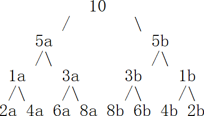

isSymmetric(root)

Method 1:  
if (root == null) return true;  
return isSymmetric(root.left, root.right)

Method 2:  
return isSymmetric(root, root)

recursion analysis:

1. subproblem: f(A.left, B.right), f(A.right, B.left)
2. induction rule: f(AL, BR) && f(AR, BL) && Ao.value == Bo.value
3. base case: A == null && B == null Yes; A == null && B != null || A != null & B == null: No

```java
package laioffer;
import java.util.*;

public class Test {
  public static void main(String[] args){

  }
}

class TreeNode {
  int value;
  TreeNode left;
  TreeNode right;
}

class Solution {
  public boolean isSymmetric(TreeNode root) {
    return isSymmetric(root, root);
  }

  //Time: O(n)
  //Space: O(h), worst case O(n)
  private boolean isSymmetric(TreeNode A, TreeNode B) {
    if (A == null && B == null) {
      return true;
    }
    if (A == null || B == Null) {
      return false;
    }
    if (A.value != B.value) {
      return false;
    }
    boolean firstSymmetric = isSymmetric(A.left, B.right);
    boolean secondSymmetric = isSymmetric(A.right, B.left);
    retur firstSymmetric && secondSymmetric;
  }
}
```

Time: O($n$)  
Space: O(height). O($\log{n}$) on average, O($n$) worst case

## Problem 3: Twisted Identical

f(A, B)

1. subproblem: f(AL, BL), f(AL, BR), f(AR, BL), f(AR, BR) 2, induction rule: Ao == Bo && (f(AL, BL) && f(AR, BR) || f(AL, BR) && f(AR, BL))
2. base case: A == null && B == null: true; A == null && B != null || A != null && B == null: false

if f(AL, BR) && f(AR, BL)

Step 1: AL->BR, AR->BL

Step 2:

Step 3:

node1, node2

1. node1.value == node2.value
2. (node1.left, node2.left) && (node1.right, node2.right) || (node1.left, node2.right) && (node1.right, node2.left)

```java
public boolean isTwisted(TreeNode A, TreeNode B) {
  if (A == null && B == null) {
    return true;
  }
  if (A == null || B == null) {
    return false;
  }
  //Ao == Bo && (f(AL, BL) && f(AR, BR) || f(AL, BR) && f(AR, BL))
  return A.value == B.value && (isTwisted(A.left, B.left) && isTwisted(A.right, B.right) || isTristed(A.left, B.right) && isTristed(A.right, B.left));
}
```

Time: O($n^2$) on average  
Space: O(height)

# Binary Search Tree

## 經典例題1: How to determine a binary tree is BST?

Determine if a given binary tree is binary search tree.

Assumptions

- **There are no duplicate keys** in binary search tree
- You can assume the keys stored in the binary search tree can not be Integer.MIN_VALUE or Integer.MAX_VALUE

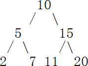

isBst(root)

1. Subproblem: isBst(root.left), isBst(root.right)
2. Induction rule: isBst(root.left) && isBst(root.right) && Lsubtree < root < Rsubtree
3. Base case: null -> true

inorder traversal -> increasing result  
2 5 7 10 11 15 20

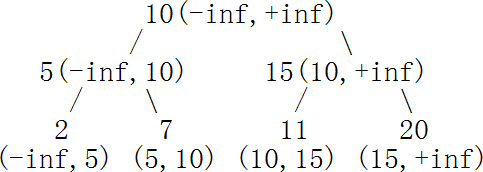

```java
class Solution {

  //Time: O(n)
  //Space: O(h)
  public boolean isBst(TreeNode root) {
    //corner case
    if (root == null) {
      return true;
    }
    return isBst(root, Integer.MIN_VALUE, Integer.MAX_VALUE);
  }
  private boolean isBst(TreeNode root, int min, int max) {
    if (root == null) {
      return true;
    }
    //because no duplicate
    if (root.value <= min || root.value >= max) {
      return false;
    }
    return isBst(root.left, min, root.value) && isBst(root.right, root.value, max);
  }
}

package laioffer;
import java.util.*;

public class Test {
  public static void main(String[] args) {
    TreeNode A = null;
    TreeNode B = null;
    Solution sol = new Solution();
    boolean aIsBST = sol.isBST(A);
    boolean bIsBST = sol.isBST(B);
  }
}

class TreeNode {
  public int value;
  public TreeNode left;
  public TreeNode right;
}
```

Time: O($n$)  
Space: O($n$) worst case; average O($\log{n}$), or O(height)

Method below not recommended, because it uses globle variable.

```java
class Solution {
  private int lastSeen = Integer.MIN_VALUE;

  public boolean isBst(TreeNode root) {
    if (root == null) {
      return true;
    }
    if (!isBst(root.left)) {
      return false;
    }
    if (root.value <= lastSeen) {
      return false;
    }
    lastSeen = root.value;

    return isBst(root.right);
  }
}
```

## 經典例題2: Print BST keys in the given range

Given two values k1 and k2 (where k1 < k2) and a root pointer to a Binary Search Tree. Print all the keys of tree in range k1 to k2. i.e., print all x such that k1 <= x <= k2 and x is a key of given BST. **Print all the keys in an increasing order.**

k1: lower  
k2: upper

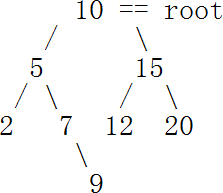

if (root < lower), don’t go left; root >= lower, go left  
if (root > upper), don’t go right; root <= upper, go right

Range: [6, 13]  
Inorder of BST: [2, 5, **7**, **9**, **10**, **12**, 15, 20] is sorted.

Step 1: determine whether we need to go left  
if (root.value <= lower_bound) then do not need to go left

Step 2: determine whether we need to go right  
if (root.value >= upper_bound) then do not need to go right

```java
//worst case is still O(n), when all the nodes are within the range [lower, upper], but, in normal cases, we'll do branch pruning, so the complexity is smaller than O(n)
public void printRange(TreeNode root, int lower, int upper) {
  if (root == null) {
    return;
  }
  if (root.value >= lower) {
    printRange(root.left, lower, upper);
  }
  if (lower <= root.value && root.value <= upper) {
    System.out.println(root.value);
  }
  if (root.value <= upper) {
    printRange(root.right, lower, upper);
  }
}
```

```java
public class Solution {
  public List<Integer> getRange(TreeNode root, int min, int max) {
    List<Integer> List = new ArrayList<Integer>();
    helper(root, min, max, list);
    return list;
  }
  private void helper(TreeNode root, int min, int max, List<Integer> list) {
    if (root == null) {
      return;
    }

    if (root.key > min) {
      helper(root.left, min, max, list);
    }
    if (min <= root.key && root.key <= max) {
      list.add(root.key);
    }
    if (root.key < max) {
      helper(root.right, min, max, list);
    }
  }
}
```

Time: worst case O($n$)  
Space: O(height)